# Part II - (Données du système Ford GoBike )

## by Clarisse TOMAVO

## Investigation Overview

> General objective of the presentation. In this project 3 of the data analysis program, we will use our skills in explanatory and exploratory visualization, while going through data wrangling to make the data clean as necessary. The end goal is to be able to discover and answer interesting questions about the dataset.

## Un apercu des cinq premieres lignes de notre jeu de données.

|  | duration_sec | start_time | end_time | start_station_id | start_station_name | start_station_latitude | start_station_longitude | end_station_id | end_station_name | end_station_latitude | end_station_longitude | bike_id | user_type | member_birth_year | member_gender | bike_share_for_all_trip | start_month | start_day |
| --- | --- | --- | --- | --- | --- | --- | --- | --- | --- | --- | --- | --- | --- | --- | --- | --- | --- | --- |
| 0 | 52185 | 2019-02-28 | 2019-03-01 | 21 | Montgomery St BART Station (Market St at 2nd St) | 37.789625 | -122.400811 | 13 | Commercial St at Montgomery St | 37.794231 | -122.402923 | 4902 | Customer | 1984.0 | Male | No | February | Thursday |
| 1 | 42521 | 2019-02-28 | 2019-03-01 | 23 | The Embarcadero at Steuart St | 37.791464 | -122.391034 | 81 | Berry St at 4th St | 37.775880 | -122.393170 | 2535 | Customer | NaN | NaN | No | February | Thursday |
| 2 | 61854 | 2019-02-28 | 2019-03-01 | 86 | Market St at Dolores St | 37.769305 | -122.426826 | 3 | Powell St BART Station (Market St at 4th St) | 37.786375 | -122.404904 | 5905 | Customer | 1972.0 | Male | No | February | Thursday |
| 3 | 36490 | 2019-02-28 | 2019-03-01 | 375 | Grove St at Masonic Ave | 37.774836 | -122.446546 | 70 | Central Ave at Fell St | 37.773311 | -122.444293 | 6638 | Subscriber | 1989.0 | Other | No | February | Thursday |
| 4 | 1585 | 2019-02-28 | 2019-03-01 | 7 | Frank H Ogawa Plaza | 37.804562 | -122.271738 | 222 | 10th Ave at E 15th St | 37.792714 | -122.248780 | 4898 | Subscriber | 1974.0 | Male | Yes | February | Thursday |

## (Visualization 1) The number of trips made by each group of customers

### Here we will find out, the types of users of the Ford GoBike system. And also discover the number of times each type of user has used the system.

```
Les différents types d'utilisateur avec le nombre de fois qu'ils ont utilisé le système.

Subscriber    163414
Customer       19801
Name: user_type, dtype: int64
```

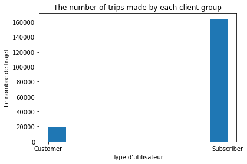

## (Visualization 2) Number of uses per day

### Let's find out the days when the systems are used the most.

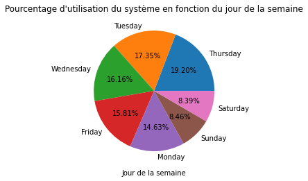

## (Visualization 3) Stations that are much more starting points for trips.

## If you want to place billboards, you can decide to place them perhaps at the stations which are often the starting point for the journeys or the stations which are often the point of arrival for the journeys.

## Let the data speak to find out.

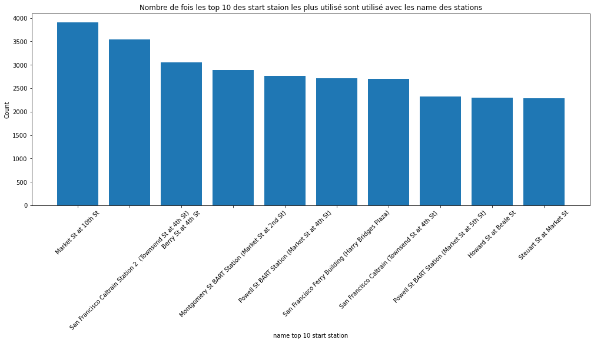

## (Visualisation4) Let's study the proximity of the top 10 departure stations

## This may let you know that most of their client resides in such place. And maybe they have things in common.

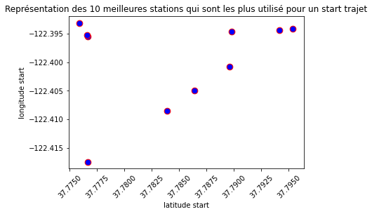

## (Visualisation5) Quel catégorie d'utilisateur dure plus pour un trajet?

```
Durée moyenne du temps passé pour les trajets par les deux types d'utilisateur du système.

            duration_sec
user_type
Customer     1433.475734
Subscriber    640.164766
```

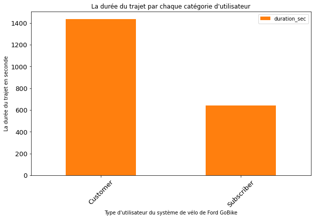

## (Visualization6) Bike system usage time report by user type per day

## This, to be able to know which promotion is done by targeting customer categories.

```
''
```

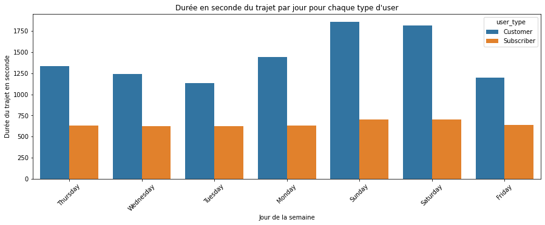

### Merci pour l'attention!

### 11/11/2022